# GEOG 215 Project

Blaine Jenkins

2023-11-30

## Project Task #1

### Topic

Housing in Boston, MA

### Interest

I’m interested in looking at housing in Boston primarily for a personal reason. I’m graduating next May and Boston is on my list of possible places to move and I’d like to see if it’s a viable option for myself. The importance of this topic, however, goes well beyond the scope of my own interests. Boston is one of the most gentrified cities in the US and is currently facing a housing shortage, pushing up prices and pushing out long-time residents in a racially disproportionate way.

https://dailyfreepress.com/2021/02/18/boston-remains-highly-gentrified-despite-housing-efforts/

The article linked above gives good background on the recent gentrification in Boston and claims efforts to create new housing have only accelerated the process. I would like to see the spatial relationship over time of new housing and average income in neighborhoods to verify this.

https://www.bu.edu/articles/2022/greater-boston-housing-earns-failing-grade-in-annual-report/

This article speaks more to the Boston housing shortage and how it widens racial disparities in terms of home ownership and renting. It would be interesting to see the change in the relationship between race and home ownership in recent years, or to see the change in race and income in historically redlined neighborhoods to see the effects of gentrification.

### Data

From the American Community Survey, I would like to use the Value of Home variable as my main variable at the census block group for the greater Boston area.

## Project Task #2

## Project Task #3

```r
# Load libraries
library(tidyverse)
library(sf)
library(readxl)
library(tmap)
```

### Data Preparation

```r
# Read in National Risk Index MA tract data
ma_nri <- read_csv("../Raw_Data/NRI_Table_CensusTracts_Massachusetts.zip")

# Read in ACS 2013 data
bostv <- read_sf("../Raw_Data/acs21.gpkg")

# Keep the ACS important columns
bostv <- bostv |> select(GEOID, geom, ends_with("E"), -2)

# Rename ACS columns
bostv <- bostv |> rename(MEDVALUE = B25097_001E,
                         MEDINCOME = B25099_001E)

# Create new column for Price to Income ratio
bostv <- bostv |> mutate(PIR = MEDVALUE / MEDINCOME)

# Subset important NRI columns
ma_nri <- ma_nri |> select(TRACTFIPS, CFLD_ALRB, CFLD_RISKS)

# Rename subsetted NRI columns
ma_nri <- ma_nri |> rename(BLDG_LOSS = CFLD_ALRB,
                           RISK = CFLD_RISKS)
```

### Table Join

```r
# Convert NRI key field to char
ma_nri <- ma_nri |>
  mutate(TRACTFIPS = as.character(TRACTFIPS))

# Left join
bostv <- left_join(bostv,
                   ma_nri,
                   by = c("GEOID" = "TRACTFIPS"))
```

This join was successfully completed because the new data frame has all the variables populated. `bostv` is a has less values, so many rows of `ma_nri` cannot be found in the new data frame, but the key fields matched elsewhere.

### Summary

```r
# Calculate mean
pir_mean <- mean(bostv$PIR, na.rm = TRUE)

# Calculate min
pir_min <- min(bostv$PIR, na.rm = TRUE)

# Calculate max
pir_max <- max(bostv$PIR, na.rm = TRUE)
```

The values of Price per Income fall between 1.0195324 and 10.0555102, with a mean of 4.8648142.

### Histogram

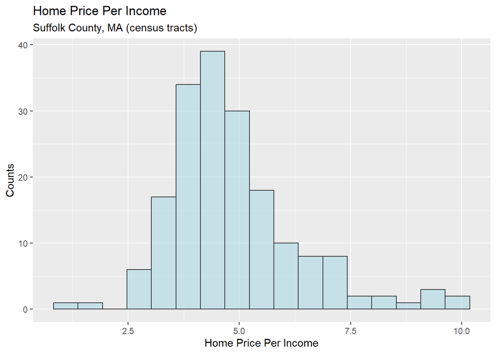

```r
# Use ggplot to make the histogram
ggplot(data = bostv,
       aes(PIR)) +
  geom_histogram(binwidth = 0.55,
                 na.rm = TRUE,
                 fill = "lightblue",
                 col = "grey20",
                 alpha = 0.6) +
  labs(title = "Home Price Per Income",
       subtitle = "Suffolk County, MA (census tracts)",
       y = "Counts",
       x = "Home Price Per Income")
```

The data is centered around 4.8, with a skew to the right. If it weren’t for the skew, the data would be relatively bell-shaped.

### Choropleth Map

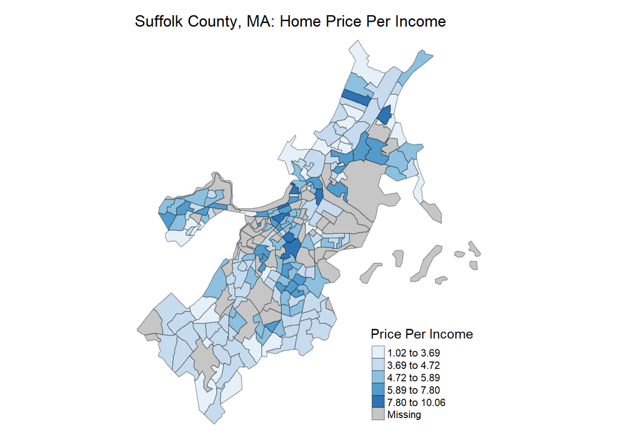

```r
# Use tmap to make a map
tm_shape(bostv) +
  tm_polygons("PIR",
              title = "Price Per Income",
              style = "jenks",
              palette = "Blues",
              alpha = 0.9,                   ## Transparency for the polygon fills
              border.col = "black",          ## Color for the polygon lines
              border.alpha = 0.3,) +
  tm_layout(main.title = "Suffolk County, MA: Home Price Per Income",
            main.title.size = 1.1,
            frame = FALSE)
```

Homes with a higher price per income are clustered together toward the center of the county. The area surrounding the bay also shows a higher price per income than the more inland/rural parts of the county.